# Cars4U Project 3 Brandy Murray

Cars4U Project 3

Brandy Murray

Table of Contents:

1. Define the Problem  
Define the problem, the objective, and the data dictionary.  
2. Load the Libraries & Explore the Data  
Load and explore the dataset.  
3. Processing Columns  
Create uniformity among columns that contain labels and/or mixed data types.  
4. Perform an Exploratory Data Analysis  
Extract insights using both Univariate and Bivariate analysis.  
5. Data Pre-Processing & Feature Engineering  
Perform necessary Data Pre-Processing including: Missing Value Treatment, Outlier Treatment, and Feature Engineering.  
6. Linear Regression Model Building  
Build a Linear Regression model and comment on the model statistics. Identify the key variables that have a strong relationship with the dependent variable.  
7. Test Assumptions of the Linear Regression Model  
Perform tests for the assumptions of the linear regression and comment on the findings from the test.  
8. Model Performance Evaluation  
Evaluate the model on different performance metrics and comment on the performance and scope of improvement.  
9. Actionable Insights & Recommendations  
Conclude with the key takeaways for the business specifically, what would your advice be to grow the business?

Description

There is a huge demand for used cars in the Indian Market today. As sales of new cars have slowed down in the recent past, the pre-owned car market has continued to grow over the past years and is larger than the new car market now. Cars4U is a budding tech start-up that aims to find footholes in this market.

In 2018-19, while new car sales were recorded at 3.6 million units, around 4 million second-hand cars were bought and sold. There is a slowdown in new car sales and that could mean that the demand is shifting towards the pre-owned market. In fact, some car sellers replace their old cars with pre-owned cars instead of buying new ones. Unlike new cars, where price and supply are fairly deterministic and managed by OEMs (Original Equipment Manufacturer / except for dealership level discounts which come into play only in the last stage of the customer journey), used cars are very different beasts with huge uncertainty in both pricing and supply. Keeping this in mind, the pricing scheme of these used cars becomes important in order to grow in the market.

As a senior data scientist at Cars4U, you have to come up with a pricing model that can effectively predict the price of used cars and can help the business in devising profitable strategies using differential pricing. For example, if the business knows the market price, it will never sell anything below it.

Objective

1. Explore and visualize the dataset.
2. Build a linear regression model to predict the prices of used cars.
3. Generate a set of insights and recommendations that will help the business.

Data Dictionary

1. S.No.: Serial Number
2. Name: Name of the car which includes Brand name and Model name
3. Location: The location in which the car is being sold or is available for purchase Cities
4. Year: Manufacturing year of the car
5. Kilometers_driven: The total kilometers driven in the car by the previous owner(s) in KM.
6. Fuel_Type: The type of fuel used by the car. (Petrol, Diesel, Electric, CNG, LPG)
7. Transmission: The type of transmission used by the car. (Automatic / Manual)
8. Owner: Type of ownership
9. Mileage: The standard mileage offered by the car company in kmpl or km/kg
10. Engine: The displacement volume of the engine in CC.
11. Power: The maximum power of the engine in bhp.
12. Seats: The number of seats in the car.
13. New_Price: The price of a new car of the same model in INR Lakhs.(1 Lakh = 100, 000)
14. Price: The price of the used car in INR Lakhs (1 Lakh = 100, 000)

Load the Libraries & Explore the Data

Import Libraries

```python
# This will help in making the Python code more structured automatically (good coding practice)
%load_ext nb_black

# Import necessary libraries
import warnings

warnings.filterwarnings("ignore")

import numpy as np
import pandas as pd
import matplotlib.pyplot as plt
import seaborn as sns
import statsmodels.api as sm

# Removes the limit for the number of displayed columns
pd.set_option("display.max_columns", None)
# Sets the limit for the number of displayed rows
pd.set_option("display.max_rows", 200)

# To enable plotting graphs in Jupyter notebook
%matplotlib inline

# To build linear regression_model
from sklearn.linear_model import LinearRegression

# To check model performance
from sklearn.metrics import mean_absolute_error, mean_squared_error, r2_score

# Sklearn package's randomized data splitting function
from sklearn.model_selection import (
    train_test_split,
)
```

Load and Explore Data

```python
# Load the data into pandas dataframe
data = pd.read_csv("used_cars_data.csv")
```

```python
# Copy the data
df = data.copy()
```

```python
# Printing the shape of the data in an f-string
print(f"There are {df.shape[0]} rows and {df.shape[1]} columns.")
```

```
There are 7253 rows and 14 columns.
```

```python
# This shows the first 5 rows of data
df.head()
```

|  | S.No. | Name | Location | Year | Kilometers_Driven | Fuel_Type | Transmission | Owner_Type | Mileage | Engine | Power | Seats | New_Price | Price |
| --- | --- | --- | --- | --- | --- | --- | --- | --- | --- | --- | --- | --- | --- | --- |
| 0 | 0 | Maruti Wagon R LXI CNG | Mumbai | 2010 | 72000 | CNG | Manual | First | 26.6 km/kg | 998 CC | 58.16 bhp | 5.0 | NaN | 1.75 |
| 1 | 1 | Hyundai Creta 1.6 CRDi SX Option | Pune | 2015 | 41000 | Diesel | Manual | First | 19.67 kmpl | 1582 CC | 126.2 bhp | 5.0 | NaN | 12.50 |
| 2 | 2 | Honda Jazz V | Chennai | 2011 | 46000 | Petrol | Manual | First | 18.2 kmpl | 1199 CC | 88.7 bhp | 5.0 | 8.61 Lakh | 4.50 |
| 3 | 3 | Maruti Ertiga VDI | Chennai | 2012 | 87000 | Diesel | Manual | First | 20.77 kmpl | 1248 CC | 88.76 bhp | 7.0 | NaN | 6.00 |
| 4 | 4 | Audi A4 New 2.0 TDI Multitronic | Coimbatore | 2013 | 40670 | Diesel | Automatic | Second | 15.2 kmpl | 1968 CC | 140.8 bhp | 5.0 | NaN | 17.74 |

```python
# I'm now going to look at 10 random rows
# I'm setting the random seed via np.random.seed so that
# I get the same random results every time
np.random.seed(1)
df.sample(n=10)
```

|  | S.No. | Name | Location | Year | Kilometers_Driven | Fuel_Type | Transmission | Owner_Type | Mileage | Engine | Power | Seats | New_Price | Price |
| --- | --- | --- | --- | --- | --- | --- | --- | --- | --- | --- | --- | --- | --- | --- |
| 2397 | 2397 | Ford EcoSport 1.5 Petrol Trend | Kolkata | 2016 | 21460 | Petrol | Manual | First | 17.0 kmpl | 1497 CC | 121.36 bhp | 5.0 | 9.47 Lakh | 6.00 |
| 3777 | 3777 | Maruti Wagon R VXI 1.2 | Kochi | 2015 | 49818 | Petrol | Manual | First | 21.5 kmpl | 1197 CC | 81.80 bhp | 5.0 | 5.44 Lakh | 4.11 |
| 4425 | 4425 | Ford Endeavour 4x2 XLT | Hyderabad | 2007 | 130000 | Diesel | Manual | First | 13.1 kmpl | 2499 CC | 141 bhp | 7.0 | NaN | 6.00 |
| 3661 | 3661 | Mercedes-Benz E-Class E250 CDI Avantgrade | Coimbatore | 2016 | 39753 | Diesel | Automatic | First | 13.0 kmpl | 2143 CC | 201.1 bhp | 5.0 | NaN | 35.28 |
| 4514 | 4514 | Hyundai Xcent 1.2 Kappa AT SX Option | Kochi | 2016 | 45560 | Petrol | Automatic | First | 16.9 kmpl | 1197 CC | 82 bhp | 5.0 | NaN | 6.34 |
| 599 | 599 | Toyota Innova Crysta 2.8 ZX AT | Coimbatore | 2019 | 40674 | Diesel | Automatic | First | 11.36 kmpl | 2755 CC | 171.5 bhp | 7.0 | 28.05 Lakh | 24.82 |
| 186 | 186 | Mercedes-Benz E-Class E250 CDI Avantgrade | Bangalore | 2014 | 37382 | Diesel | Automatic | First | 13.0 kmpl | 2143 CC | 201.1 bhp | 5.0 | NaN | 32.00 |
| 305 | 305 | Audi A6 2011-2015 2.0 TDI Premium Plus | Kochi | 2014 | 61726 | Diesel | Automatic | First | 17.68 kmpl | 1968 CC | 174.33 bhp | 5.0 | NaN | 20.77 |
| 4582 | 4582 | Hyundai i20 1.2 Magna | Kolkata | 2011 | 36000 | Petrol | Manual | First | 18.5 kmpl | 1197 CC | 80 bhp | 5.0 | NaN | 2.50 |
| 5434 | 5434 | Honda WR-V Edge Edition i-VTEC S | Kochi | 2019 | 13913 | Petrol | Manual | First | 17.5 kmpl | 1199 CC | 88.7 bhp | 5.0 | 9.36 Lakh | 8.20 |

```python
# This shows the last 5 rows of the data
df.tail()
```

|  | S.No. | Name | Location | Year | Kilometers_Driven | Fuel_Type | Transmission | Owner_Type | Mileage | Engine | Power | Seats | New_Price | Price |
| --- | --- | --- | --- | --- | --- | --- | --- | --- | --- | --- | --- | --- | --- | --- |
| 7248 | 7248 | Volkswagen Vento Diesel Trendline | Hyderabad | 2011 | 89411 | Diesel | Manual | First | 20.54 kmpl | 1598 CC | 103.6 bhp | 5.0 | NaN | NaN |
| 7249 | 7249 | Volkswagen Polo GT TSI | Mumbai | 2015 | 59000 | Petrol | Automatic | First | 17.21 kmpl | 1197 CC | 103.6 bhp | 5.0 | NaN | NaN |
| 7250 | 7250 | Nissan Micra Diesel XV | Kolkata | 2012 | 28000 | Diesel | Manual | First | 23.08 kmpl | 1461 CC | 63.1 bhp | 5.0 | NaN | NaN |
| 7251 | 7251 | Volkswagen Polo GT TSI | Pune | 2013 | 52262 | Petrol | Automatic | Third | 17.2 kmpl | 1197 CC | 103.6 bhp | 5.0 | NaN | NaN |
| 7252 | 7252 | Mercedes-Benz E-Class 2009-2013 E 220 CDI Avan... | Kochi | 2014 | 72443 | Diesel | Automatic | First | 10.0 kmpl | 2148 CC | 170 bhp | 5.0 | NaN | NaN |

Looking at these 10 random rows, we can see that it'll be safe to drop the included S.No. and just work with the generated ID because the numbers are the same.  
We can also see that right now there are some columns that are represented as strings but we really will want to make them numeric. This includes columns like Mileage, Engine, and Power.  
If New Price is determined to be kept we will want to change this to a numeric as well. But because this variable has some missing data, we will need to determine whether we want to keep this column or drop it.  
I also am not sure why Seat is a float. I have never heard of a car that has half a seat.

```python
# Dropping 'S.No.' as stated above
df.drop("S.No.", axis=1, inplace=True)
```

```python
# This converts the price to the extended form
print(df["Price"].head(2))
df["Price"] = df["Price"].apply(lambda wt: round(wt * 100000, 2))
df["Price"].head(2)
```

```
0     1.75
1    12.50
Name: Price, dtype: float64
```

```
0     175000.0
1    1250000.0
Name: Price, dtype: float64
```

```python
df["Name"].head()
```

```
0              Maruti Wagon R LXI CNG
1    Hyundai Creta 1.6 CRDi SX Option
2                        Honda Jazz V
3                   Maruti Ertiga VDI
4     Audi A4 New 2.0 TDI Multitronic
Name: Name, dtype: object
```

```python
namesplit = df["Name"].str.split(" ", n=1, expand=True)
namesplit.head()
```

|  | 0 | 1 |
| --- | --- | --- |
| 0 | Maruti | Wagon R LXI CNG |
| 1 | Hyundai | Creta 1.6 CRDi SX Option |
| 2 | Honda | Jazz V |
| 3 | Maruti | Ertiga VDI |
| 4 | Audi | A4 New 2.0 TDI Multitronic |

```python
df.drop(["Name"], axis=1, inplace=True)
df["Brand"] = namesplit[0]
df["Model"] = namesplit[1]

del namesplit  # don't need to do this but can keep things tidy
```

```python
df.head()
```

|  | Location | Year | Kilometers_Driven | Fuel_Type | Transmission | Owner_Type | Mileage | Engine | Power | Seats | New_Price | Price | Brand | Model |
| --- | --- | --- | --- | --- | --- | --- | --- | --- | --- | --- | --- | --- | --- | --- |
| 0 | Mumbai | 2010 | 72000 | CNG | Manual | First | 26.6 km/kg | 998 CC | 58.16 bhp | 5.0 | NaN | 175000.0 | Maruti | Wagon R LXI CNG |
| 1 | Pune | 2015 | 41000 | Diesel | Manual | First | 19.67 kmpl | 1582 CC | 126.2 bhp | 5.0 | NaN | 1250000.0 | Hyundai | Creta 1.6 CRDi SX Option |
| 2 | Chennai | 2011 | 46000 | Petrol | Manual | First | 18.2 kmpl | 1199 CC | 88.7 bhp | 5.0 | 8.61 Lakh | 450000.0 | Honda | Jazz V |
| 3 | Chennai | 2012 | 87000 | Diesel | Manual | First | 20.77 kmpl | 1248 CC | 88.76 bhp | 7.0 | NaN | 600000.0 | Maruti | Ertiga VDI |
| 4 | Coimbatore | 2013 | 40670 | Diesel | Automatic | Second | 15.2 kmpl | 1968 CC | 140.8 bhp | 5.0 | NaN | 1774000.0 | Audi | A4 New 2.0 TDI Multitronic |

```python
# looking at which columns have the most missing values
df.isnull().sum().sort_values(ascending=False)
```

```
New_Price            6247
Price                1234
Seats                  53
Power                  46
Engine                 46
Mileage                 2
Model                   0
Brand                   0
Owner_Type              0
Transmission            0
Fuel_Type               0
Kilometers_Driven       0
Year                    0
Location                0
dtype: int64
```

From the initial look at the random rows, I thought the majority of New Price was going to be missing and this shows that thought is correct, 6247 values of a total 7253 are missing. There are quite a few of Price missing as well with just a few of Seats, Power, Engine, and Mileage.

3. Processing Columns

Columns Containing Labels

```python
"""This function looks at each object column and looks for the labels listed.
Then it outputs a list of the columns that contain these labels"""
s_labels = "null"
e_labels = ("bhp", "CC", "kmpl", "km/kg")
label_cols = []
for colname in df.columns[
    df.dtypes == "object"
]:  # only need to consider string columns
    if df[colname].str.startswith(s_labels).any():
        label_cols.append(colname)
    elif (
        df[colname].str.endswith(e_labels).any()
    ):  # using `.str` so I can use an element-wise string method
        label_cols.append(colname)
print(label_cols)
```

```
['Mileage', 'Engine', 'Power']
```

```python
"""With a list of columns we can apply a replace to remove the labels. Under
Power there are some rows that have null bhp. The first if statement takes care
of the null by changing it to a NaN"""


def removing_labels(label_val):
    if isinstance(label_val, str):  # checks if 'label_val' is a string
        if label_val.startswith("null"):
            return np.nan
        elif label_val.endswith(" bhp"):
            return float(label_val.replace(" bhp", ""))
        elif label_val.endswith(" CC"):
            return float(label_val.replace(" CC", ""))
        elif (label_val.endswith(" kmpl")) or (label_val.endswith(" km/kg")):
            return float(label_val.replace(" kmpl", "").replace(" km/kg", ""))
    else:
        return np.nan


for colname in label_cols:
    df[colname] = df[colname].apply(removing_labels)

df[label_cols].head()
```

|  | Mileage | Engine | Power |
| --- | --- | --- | --- |
| 0 | 26.60 | 998.0 | 58.16 |
| 1 | 19.67 | 1582.0 | 126.20 |
| 2 | 18.20 | 1199.0 | 88.70 |
| 3 | 20.77 | 1248.0 | 88.76 |
| 4 | 15.20 | 1968.0 | 140.80 |

```python
"""this loop prints the names of the columns where there is
at least one entry ending with the label Cr"""
labels = "Cr"
newprice_cols = []
for colname in df.columns[
    df.dtypes == "object"
]:  # only need to consider string columns
    if (
        df[colname].str.endswith(labels).any()
    ):  # using `.str` so I can use an element-wise string method
        newprice_cols.append(colname)
print(newprice_cols)
```

```
['New_Price']
```

```python
"""Because Cr and Lakh have different conversions,
we need to convert Cr to Lakh before removing the labels
and turning the variable into a float"""


def convert_price(new_val):
    if isinstance(new_val, str):
        multiplier = 1
        if new_val.endswith("Cr"):
            multiplier = 100
        elif new_val.endswith("Lakh"):
            multiplier = 1
        return float(new_val.replace("Cr", "").replace("Lakh", "")) * multiplier
    else:
        return np.nan


for colname in newprice_cols:
    df[colname] = df[colname].apply(convert_price)

df[newprice_cols].head()
```

|  | New_Price |
| --- | --- |
| 0 | NaN |
| 1 | NaN |
| 2 | 8.61 |
| 3 | NaN |
| 4 | NaN |

Now everything that should be numeric is and we can start looking at summary statistics and do an Exploratory Analysis.

4. Perform an Exploratory Data Analysis

Univariate Analysis

Summary Statistics of Numeric and Non-Numeric Variables

```python
# This provides a quick summary of the numeric features
df.describe().T
```

|  | count | mean | std | min | 25% | 50% | 75% | max |
| --- | --- | --- | --- | --- | --- | --- | --- | --- |
| Year | 7253.0 | 2013.365366 | 3.254421e+00 | 1996.00 | 2011.000 | 2014.00 | 2016.0000 | 2019.00 |
| Kilometers_Driven | 7253.0 | 58699.063146 | 8.442772e+04 | 171.00 | 34000.000 | 53416.00 | 73000.0000 | 6500000.00 |
| Mileage | 7251.0 | 18.141580 | 4.562197e+00 | 0.00 | 15.170 | 18.16 | 21.1000 | 33.54 |
| Engine | 7207.0 | 1616.573470 | 5.952851e+02 | 72.00 | 1198.000 | 1493.00 | 1968.0000 | 5998.00 |
| Power | 7078.0 | 112.765214 | 5.349355e+01 | 34.20 | 75.000 | 94.00 | 138.1000 | 616.00 |
| Seats | 7200.0 | 5.279722 | 8.116597e-01 | 0.00 | 5.000 | 5.00 | 5.0000 | 10.00 |
| New_Price | 1006.0 | 22.779692 | 2.775934e+01 | 3.91 | 7.885 | 11.57 | 26.0425 | 375.00 |
| Price | 6019.0 | 947946.835022 | 1.118792e+06 | 44000.00 | 350000.000 | 564000.00 | 995000.0000 | 16000000.00 |

```python
# Looking at value counts for non-numeric features
num_to_display = 10  # defining this up here so it's easy to change later if I want
for colname in df.dtypes[df.dtypes == "object"].index:
    val_counts = df[colname].value_counts(dropna=False)  # i want to see NA counts
    print(val_counts[:num_to_display])
    if len(val_counts) > num_to_display:
        print(f"Only displaying first {num_to_display} of {len(val_counts)} values.")
    print("\n\n")  # just for more space between
```

```
Mumbai        949
Hyderabad     876
Kochi         772
Coimbatore    772
Pune          765
Delhi         660
Kolkata       654
Chennai       591
Jaipur        499
Bangalore     440
Name: Location, dtype: int64
Only displaying first 10 of 11 values.



Diesel      3852
Petrol      3325
CNG           62
LPG           12
Electric       2
Name: Fuel_Type, dtype: int64



Manual       5204
Automatic    2049
Name: Transmission, dtype: int64



First             5952
Second            1152
Third              137
Fourth & Above      12
Name: Owner_Type, dtype: int64



Maruti           1444
Hyundai          1340
```

[output cut: 10 more lines]

```



XUV500 W8 2WD          55
Swift VDI              49
Swift Dzire VDI        42
City 1.5 S MT          39
Swift VDI BSIV         37
Fortuner 3.0 Diesel    35
Ritz VDi               35
Grand i10 Sportz       32
Brio S MT              32
Amaze S i-Dtech        32
Name: Model, dtype: int64
Only displaying first 10 of 2041 values.
```

```python
# While doing univariate analysis of numerical variables we want to study their central tendency and dispersion.
# Let us write a function that will help us create boxplot and histogram for any input numerical variable.
# This function takes the numerical column as the input and returns the boxplots and histograms for the variable.
# Let us see if this help us write faster and cleaner code.


def histogram_boxplot(feature, figsize=(12, 15), bins=None):
    """Boxplot and histogram combined
    feature: 1-d feature array
    figsize: size of fig (default (9,8))
    bins: number of bins (default None / auto)
    """
    sns.set(font_scale=2)  # setting the font scale for seaborn
    f2, (ax_box2, ax_hist2) = plt.subplots(
        nrows=2,  # Number of rows of the subplot grid=2
        sharex=True,  # x-axis will be shared among all subplots
        gridspec_kw={"height_ratios": (0.25, 0.75)},
        figsize=figsize,
    )  # creating the 2 subplots
    sns.boxplot(
        feature, ax=ax_box2, showmeans=True, color="violet"
    )  # boxplot will be created and a star will indicate the mean value of the column
    sns.distplot(
        feature, kde=F, ax=ax_hist2, bins=bins, palette="winter"
    ) if bins else sns.distplot(
        feature, kde=False, ax=ax_hist2
    )  # For histogram
    ax_hist2.axvline(
        feature.mean(), color="green", linestyle="--"
    )  # Add mean to the histogram
    ax_hist2.axvline(
        feature.median(), color="black", linestyle="-"
    )  # Add median to the histogram
```

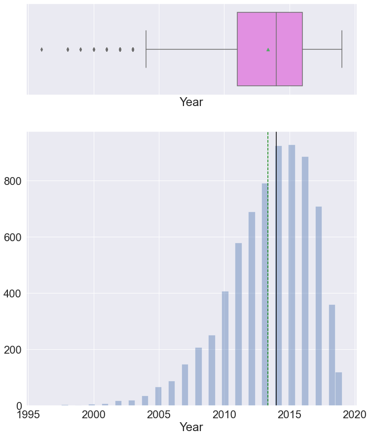

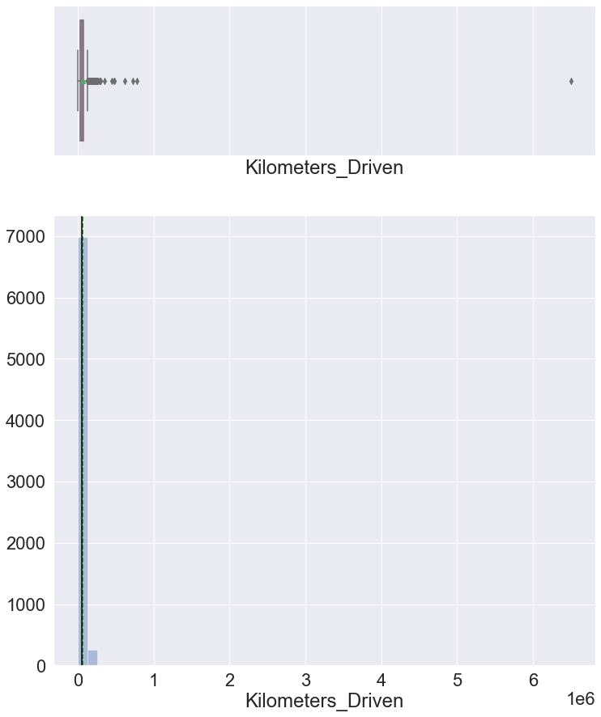

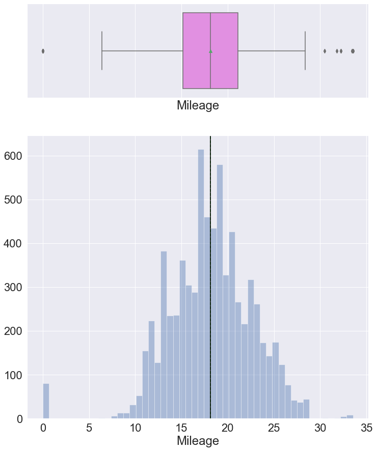

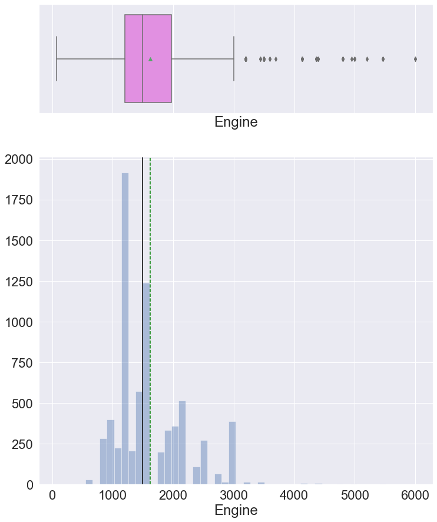

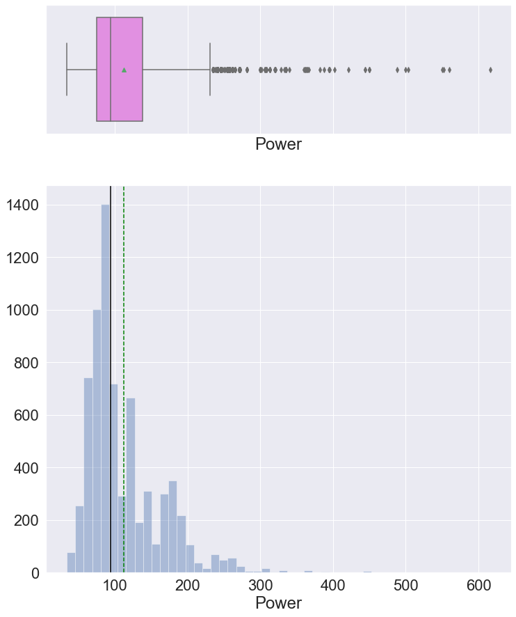

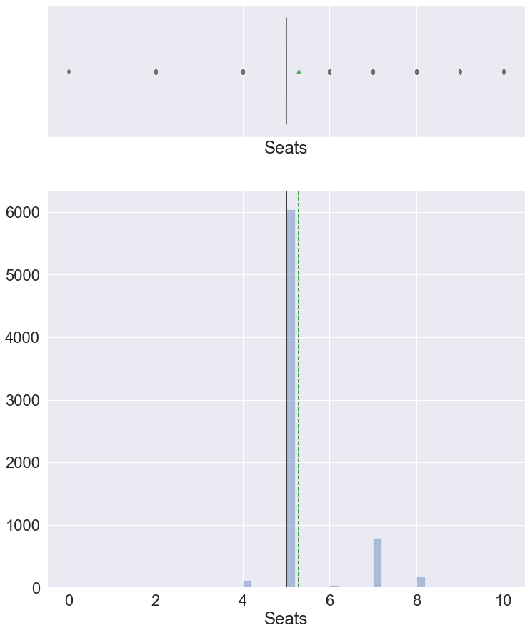

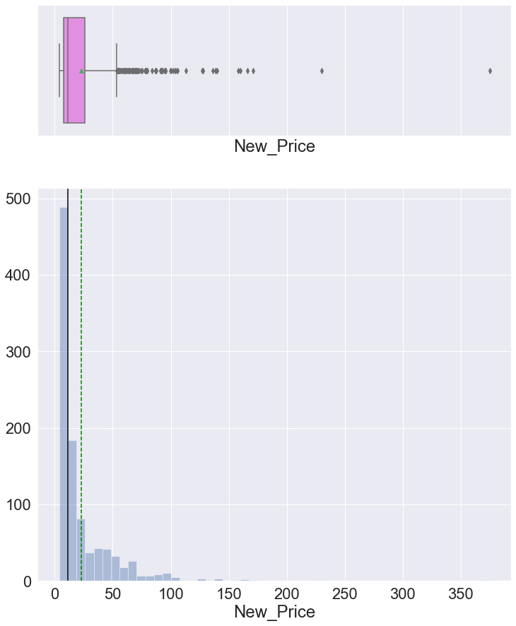

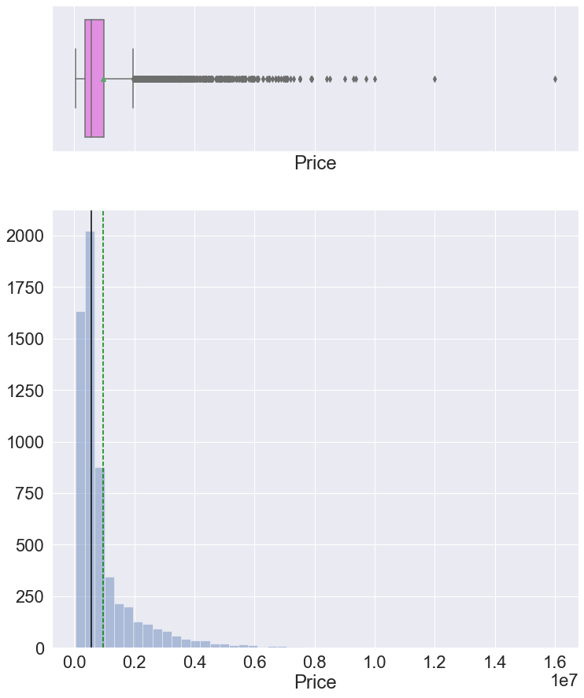

```python
num_col = df.select_dtypes(include=np.number).columns.tolist()

for col in num_col:
    histogram_boxplot(df[col])
```

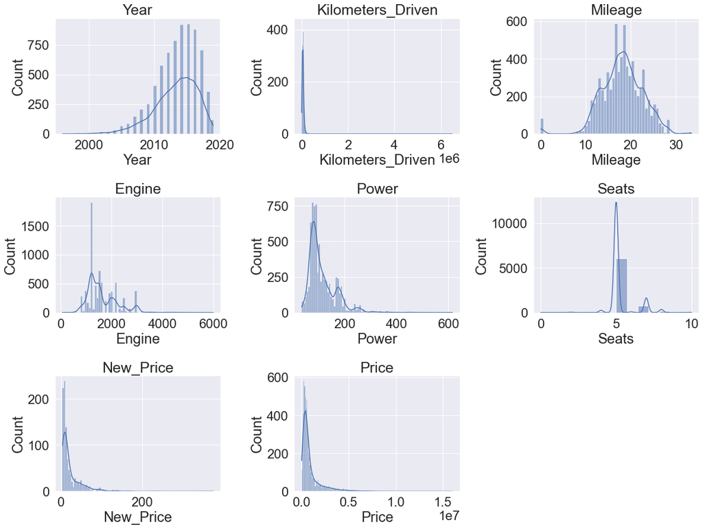

```python
# lets plot histogram of all numerical variables

all_col = df.select_dtypes(include=np.number).columns.tolist()
plt.figure(figsize=(17, 75))

for i in range(len(all_col)):
    plt.subplot(18, 3, i + 1)
    # plt.hist(df[all_col[i]])
    sns.histplot(
        df[all_col[i]], kde=True
    )  # you can comment the previous line and run this one to get distribution curves
    plt.tight_layout()
    plt.title(all_col[i], fontsize=25)

plt.show()
```

```python
print(
    f"""* The variable Year is left skewed with the median {round(df.Year.median(),2)} being slightly larger than the mean {round(df.Year.mean(),2)}.
There isn't that big of a difference though and we should look at data the boxplot is considering an outlier."""
)
print(" ")
print(
    f"""* The variable Kilometers_Driven is right skewed with the median {round(df.Kilometers_Driven.median(),2)} being smaller than the mean {round(df.Kilometers_Driven.mean(),2)}.
This is not being represented in this visualization though because the scale for the Kilometers_Driven is so large.
We will need to do further analysis on this variable."""
)
print(" ")
print(
    f"""* The variable Mileage has a normal distribution with the median {round(df.Mileage.median(),2)} and the mean {round(df.Mileage.mean(),2)} being equal
to each other."""
)
print(" ")
print(
    f"""* The variable Engine is a bit right skewed with the median {round(df.Engine.median(),2)} being slightly smaller than the mean {round(df.Engine.mean(),2)}.
However, this again could be because of the scale used for Engine. We can try further analysis to see if we can get a
better picture of this variable. We should also look into the data the boxplot is calling an outlier to see if those
numbers could be causing some issues with the skewedness."""
)
print(" ")
print(
    f"""* The variable Power is right skewed with the median {round(df.Power.median(),2)} being smaller than the mean {round(df.Power.mean(),2)}. We could see
what a log transformation could look like for this and evaluate what the boxplot is calling the outliers."""
)
print(" ")
print(
    f"""* The variable Seats should almost be considered a categorical variable since the meaning of the number is not strictly
numerical. In this case the median {round(df.Seats.median(),2)} and the mean {round(df.Seats.mean(),2)} are almost equal but the variance in this is not great.
We should run the model with this variable as both numerical and categorical to see what provides the best results."""
)
print(" ")
print(
    f"""* The variable New_Price is skewed to the right with the median {round(df.New_Price.median(),2)} being smaller than the mean {round(df.New_Price.mean(),2)}. It is important to
remember that this data only has 1006 out of 7253 indices. Therefore, we cannot count on this being a good representation
of what the data would like if it was tracked better."""
)
print(" ")
print(
    f"""* The variable Price is right skewed with the median {round(df.Price.median(),2)} being smaller than the mean {round(df.Price.mean(),2)}. It is interesting to see how
closely New_Price and Price look in these visualizations."""
)
```

```
* The variable Year is left skewed with the median 2014.0 being slightly larger than the mean 2013.37.
There isn't that big of a difference though and we should look at data the boxplot is considering an outlier.

* The variable Kilometers_Driven is right skewed with the median 53416.0 being smaller than the mean 58699.06.
This is not being represented in this visualization though because the scale for the Kilometers_Driven is so large.
We will need to do further analysis on this variable.

* The variable Mileage has a normal distribution with the median 18.16 and the mean 18.14 being equal
to each other.

* The variable Engine is a bit right skewed with the median 1493.0 being slightly smaller than the mean 1616.57.
However, this again could be because of the scale used for Engine. We can try further analysis to see if we can get a
better picture of this variable. We should also look into the data the boxplot is calling an outlier to see if those
numbers could be causing some issues with the skewedness.

* The variable Power is right skewed with the median 94.0 being smaller than the mean 112.77. We could see
what a log transformation could look like for this and evaluate what the boxplot is calling the outliers.

* The variable Seats should almost be considered a categorical variable since the meaning of the number is not strictly
numerical. In this case the median 5.0 and the mean 5.28 are almost equal but the variance in this is not great.
We should run the model with this variable as both numerical and categorical to see what provides the best results.

* The variable New_Price is skewed to the right with the median 11.57 being smaller than the mean 22.78. It is important to
remember that this data only has 1006 out of 7253 indices. Therefore, we cannot count on this being a good representation
of what the data would like if it was tracked better.

* The variable Price is right skewed with the median 564000.0 being smaller than the mean 947946.84. It is interesting to see how
closely New_Price and Price look in these visualizations.
```

Log Transformation

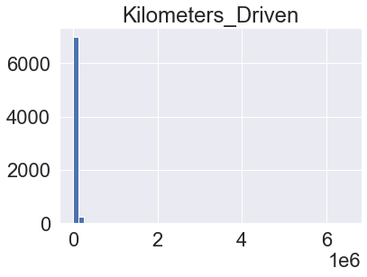

```
0
```

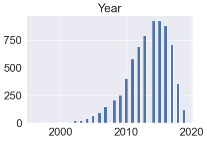

```
0
```

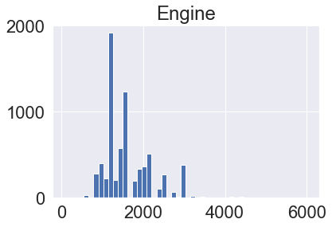

```
0
```

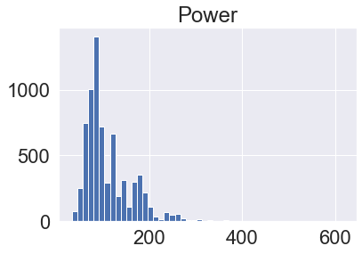

```
0
```

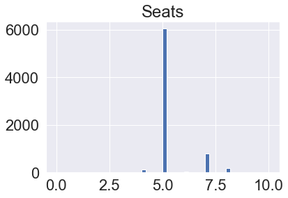

```
1
```

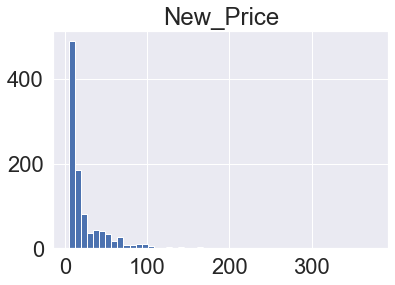

```
0
```

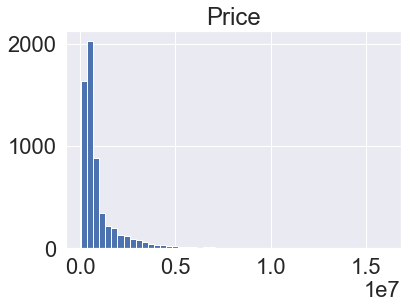

```
0
```

```python
cols_to_log = [
    "Kilometers_Driven",
    "Year",
    "Engine",
    "Power",
    "Seats",
    "New_Price",
    "Price",
]
for colname in cols_to_log:
    plt.hist(df[colname], bins=50)
    plt.title(colname)
    plt.show()
    print(np.sum(df[colname] <= 0))
```

Here we can see there are some variables that are equal to zero which will not work directly with log. Therefore, we will need to look at the other options, such as adding a small amount to every value. This will allow us to take the log and we will still get a sense of how the data is distributed. There is also taking the square root and doing the arcsinh.

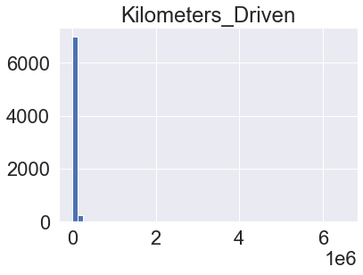

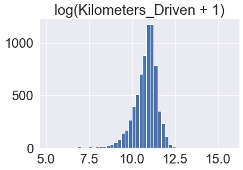

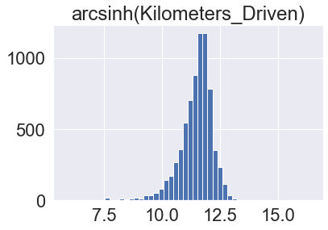

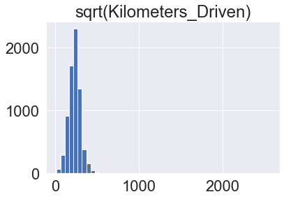

```python
plt.hist(df["Kilometers_Driven"], 50)
plt.title("Kilometers_Driven")
plt.show()
plt.hist(np.log(df["Kilometers_Driven"] + 1), 50)
plt.title("log(Kilometers_Driven + 1)")
plt.show()
plt.hist(np.arcsinh(df["Kilometers_Driven"]), 50)
plt.title("arcsinh(Kilometers_Driven)")
plt.show()
plt.hist(np.sqrt(df["Kilometers_Driven"]), 50)
plt.title("sqrt(Kilometers_Driven)")
plt.show()
```

The first visual shows what the original histogram looks like. We can see that adding one to each data point and using the arcsinh both had the same results while the sqrt method didn't work as well.

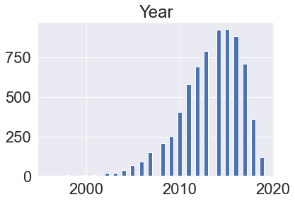

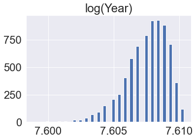

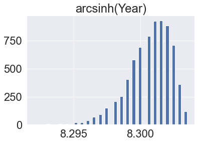

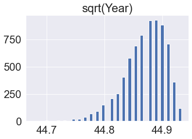

```python
plt.hist(df["Year"], 50)
plt.title("Year")
plt.show()
plt.hist(np.log(df["Year"]), 50)
plt.title("log(Year)")
plt.show()
plt.hist(np.arcsinh(df["Year"]), 50)
plt.title("arcsinh(Year)")
plt.show()
plt.hist(np.sqrt(df["Year"]), 50)
plt.title("sqrt(Year)")
plt.show()
```

Here we can see that each method looks the same as the original. I thought that might happen but wanted to check just incase.

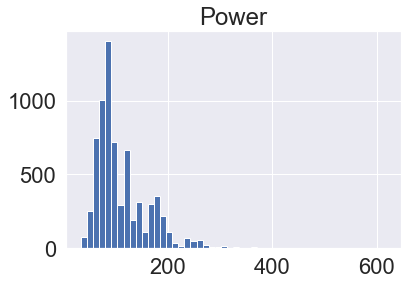

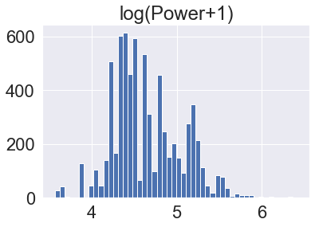

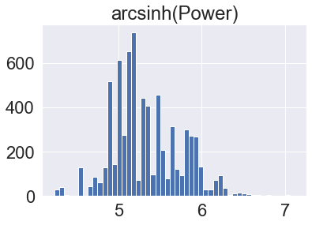

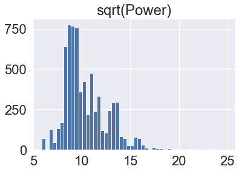

```python
plt.hist(df["Power"], 50)
plt.title("Power")
plt.show()
plt.hist(np.log(df["Power"] + 1), 50)
plt.title("log(Power+1)")
plt.show()
plt.hist(np.arcsinh(df["Power"]), 50)
plt.title("arcsinh(Power)")
plt.show()
plt.hist(np.sqrt(df["Power"]), 50)
plt.title("sqrt(Power)")
plt.show()
```

For Power we can see that all three methods worked and we can see that the data is still skewed to the right which we could see in the original visual but with the log +1 and arcsinh we can get a better idea on how the data is distributed.